# HW 1 Network Analysis

A closer look into Airport data networks in the United States.

Peter Sullivan  
2022-02-12

#### Load in DATA. This is the Airport DATA from the Google drive.

```r
load(file = "USAirports.rda")
```

#### Looking at Nodes and Edges:

```r
ls()
```

```
[1] "network_edgelist" "network_igraph"   "network_nodes"
[4] "network_statnet"
```

```r
vcount(network_igraph)
```

```
[1] 755
```

```r
ecount(network_igraph)
```

```
[1] 23473
```

```r
print(network_statnet)
```

```
 Network attributes:
  vertices = 755
  directed = TRUE
  hyper = FALSE
  loops = FALSE
  multiple = FALSE
  bipartite = FALSE
  total edges= 8228
    missing edges= 0
    non-missing edges= 8228

 Vertex attribute names:
    City Distance vertex.names

 Edge attribute names not shown
```

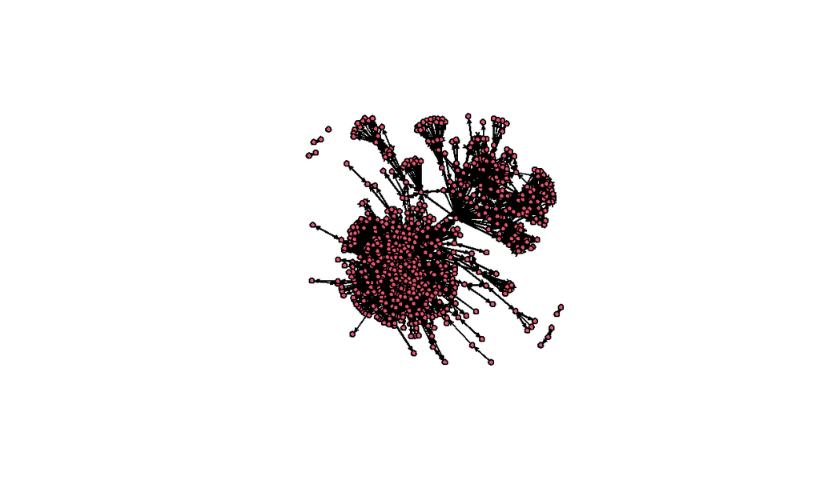

```r
#print(network_igraph)
plot(network_statnet)
```

Right off the bat, it looks like the igraph and statnet variables are showing different edges. The network igraph is showing 755 nodes and 23473 edges. The network statnet is showing 755 nodes, and 8228 edges.

#### Weighted, Directed, Single Mode Network?

```r
is_bipartite(network_igraph)
```

```
[1] FALSE
```

```r
is_directed(network_igraph)
```

```
[1] TRUE
```

```r
is_weighted(network_igraph)
```

```
[1] FALSE
```

Using the Network Igraph set, we have a single mode network, which is directed, and is not weighted.

#### Looking at Vertex and Edge Attributes:

```r
vertex_attr_names(network_igraph)
```

```
[1] "name"     "City"     "Position"
```

```r
network::list.vertex.attributes(network_statnet)
```

```
[1] "City"         "Distance"     "na"           "vertex.names"
```

```r
edge_attr_names(network_igraph)
```

```
[1] "Carrier"    "Departures" "Seats"      "Passengers" "Aircraft"
[6] "Distance"
```

```r
network::list.edge.attributes(network_statnet)
```

```
[1] "Aircraft"   "Carrier"    "Departures" "Distance"   "na"
[6] "Passangers" "Seats"      "weight"
```

Igraph Attribute Names: name, City, Position

Igraph edge names: Carrier, Departures, Seats, Passengers, Aircraft, Distance

Statnet attribute names: City, Distance, na, vertex.names

statnet edge names: Aircraft, Carrier, Departures, Distance, na, Passangers, Seats, weight

#### Accessing Attribute DATA:

```r
V(network_igraph)$name %>% head()
```

```
[1] "BGR" "BOS" "ANC" "JFK" "LAS" "MIA"
```

```r
V(network_igraph)$City %>% head()
```

```
[1] "Bangor, ME"    "Boston, MA"    "Anchorage, AK" "New York, NY"
[5] "Las Vegas, NV" "Miami, FL"
```

```r
V(network_igraph)$Position %>% head()
```

```
[1] "N444827 W0684941" "N422152 W0710019" "N611028 W1495947"
[4] "N403823 W0734644" "N360449 W1150908" "N254736 W0801726"
```

```r
(network_igraph)$Carrier %>% head()
```

```r
head(network_statnet %v% "vertex.names")
```

```
[1] "1G4" "A23" "A27" "A29" "ABE" "ABI"
```

```r
head(network_statnet %v% "City")
```

```
[1] "Bangor, ME"    "Boston, MA"    "Anchorage, AK" "New York, NY"
[5] "Las Vegas, NV" "Miami, FL"
```

```r
head(network_statnet %e% "weight")
```

```
[1] "193"  "253"  "141"  "3135" "4097" "1353"
```

#### Summarizing Attribute DATA

```r
summary(E(network_igraph)$Distance)
```

```
   Min. 1st Qu.  Median    Mean 3rd Qu.    Max.
      0     223     496     639     903    6089
```

```r
summary(network_statnet %e% "Distance")
```

```
   Length     Class      Mode
     8228 character character
```

The way the summary function worked on the statnet set makes me think the statnet dataset is incorrectly set up at the moment.  
#### Dyad Census

```r
dyad.census(network_igraph)
```

```
$mut
[1] 10449

$asym
[1] 2574

$null
[1] 271612
```

```r
sna::dyad.census(network_statnet)
```

```
      Mut Asym   Null
[1,] 3605 1018 280012
```

#### Triad Census

```r
triad.census(network_igraph)
```

```
 [1] 68169544   665870  2427052     1445     1289     2465    15322
 [8]    19171       91       39   114868      202      376      558
[15]     6422    18671
```

```r
sna::triad.census(network_statnet)
```

```
          003    012     102 021D 021U 021C  111D  111U 030T 030C
[1,] 68169544 712579 2380343 1445 1289 2465 15322 19171   91   39
        201 120D 120U 120C  210   300
[1,] 114868  202  376  558 6422 18671
```

#### Transivity

```r
transitivity(network_igraph)
```

```
[1] 0.3384609
```

```r
gtrans(network_statnet)
```

```
[1] 0.3266617
```

The transitivity for igraph and statnet data sets were pretty close.

#### Local Transivity

```r
first_five_names <- V(network_igraph)$name %>% head(5)
first_five_names
```

```
[1] "BGR" "BOS" "ANC" "JFK" "LAS"
```

```r
first_five_transivity <- transitivity(network_igraph, type = "local", vids = V(network_igraph)[first_five_names])

cbind(first_five_names,first_five_transivity)
```

```
     first_five_names first_five_transivity
[1,] "BGR"            "0.581818181818182"
[2,] "BOS"            "0.35292389068469"
[3,] "ANC"            "0.0824960338445267"
[4,] "JFK"            "0.385964912280702"
[5,] "LAS"            "0.223852116875373"
```

```r
transitivity(network_igraph, type = "global")
```

```
[1] 0.3384609
```

```r
transitivity(network_igraph, type = "average")
```

```
[1] 0.6452844
```

LA seems to have low transivity while BGR has the highest at .58.

#### Distances in the Network

```r
distances(network_igraph, "BGR","BOS")
```

```
    BOS
BGR   1
```

```r
distances(network_igraph,"BOS", "ANC")
```

```
    ANC
BOS   2
```

```r
average.path.length(network_igraph)
```

```
[1] 3.52743
```

```r
average.path.length(network_igraph, directed = F)
```

```
[1] 3.447169
```

#### Identifying Isolates

```r
names(igraph::components(network_igraph))
```

```
[1] "membership" "csize"      "no"
```

```r
components(network_igraph)$no
```

```
[1] 6
```

```r
components(network_igraph)$csize
```

```
[1] 745   2   2   3   2   1
```

```r
components(network_igraph)$membership %>% head()
```

```
BGR BOS ANC JFK LAS MIA
  1   1   1   1   1   1
```

```r
#Isolates
isolates(network_statnet)
```

```
[1] 166
```

```r
as.vector(network_statnet %v% "vertex.names")[c(isolates(network_statnet))]
```

```
[1] "DET"
```

Detroit seems to be the only isolate.